# Key findings - matched to report

Authors

Jolyon Miles-Wilson

Celestin Okoroji

Published

January 22, 2025

# 1 Chapter 2: How many outsourced workers are there in the UK?

## 1.1 How many UK workers are outsourced?

**#how-many**

**1 in 6 (17%) of UK workers are outsourced.**[^1]

In terms of the the different possible types of outsourced groups[^2], the numbers are as follows:

1. Definitely outsourced: 11%
2. Likely agency: 3%
3. High indicators: 3%

People included in this sub-group (either uniquely, or while also meeting the criteria for at least one of the other sub-groups) make up around 68% of our total outsourced group. This group makes up 11% of all UK workers.

**#non-exclusive-subgroups1**

**The percentages here refer to the number of people who are outsourced (super-ordinate group), not the total number of respondents.** Below I provide percentages as function of the outsourced super-ordinate group as well as the total sample

Group criteria

- **Outsourced**, defined as responding ‘I am sure I am outsourced’ or ‘I might be outsourced’, and responding ‘I do work on a long-term basis’.
- **Likely agency**, defined as those responding ‘I am sure I am agency’ and ‘I do work on a long-term basis’, **excluding** those people who are already defined as being outsourced.
- **High indicators**: defined as responding TRUE to 5 or 6 of the outsourcing indicators, as well as responding ‘I do work on a long-term basis’, **excluding** those people who are already defined as outsourced or likely agency.

Including outsourced group

| agency_or_indicator | freq | n | total | perc | N |
| --- | --- | --- | --- | --- | --- |
| agency | 342.6956 | 344 | 10155 | 3.374649 | 10155 |
| both | 106.3656 | 116 | 10155 | 1.047421 | 10155 |
| indicator | 513.2645 | 516 | 10155 | 5.054303 | 10155 |
| neither | 9192.6744 | 9179 | 10155 | 90.523627 | 10155 |

Exluding outsourced group

| agency_or_indicator | freq | n | total | perc | N |
| --- | --- | --- | --- | --- | --- |
| agency | 231.43068 | 231 | 8993.922 | 2.5731897 | 9032 |
| both | 35.10624 | 38 | 8993.922 | 0.3903329 | 9032 |
| indicator | 280.74106 | 291 | 8993.922 | 3.1214531 | 9032 |
| neither | 8446.64421 | 8472 | 8993.922 | 93.9150243 | 9032 |

9.48% of the whole sample meet the criteria for either or both of these sub-groups. This falls to 6.08% if we exclude people who are already captured in the outsourced sub-group.

Out of those who are in the ‘outsourced’ status (i.e., the combination of the three outsourced groups), 57.99% meet the criteria for either or both of these sub-groups, but this falls to around 33.27% if we exclude people who are already captured in the outsourced sub-group.

**#non-exclusive-subgroups2**

- There is some overlap between these sub-groups, but they are not like for like. Just over a quarter (27%) of respondents are in more than one sub-group, while nearly three quarters (73%) of respondents are uniquely captured in just one of the three sub-groups.

Just over a quarter (26.35%) of respondents are in more than one sub-group, while nearly three quarters (73.65%) of respondents are uniquely captured in just one of the three sub-groups.[^3]

## 1.2 Evaluating our total estimate

**#evaluating-total-estimate To do**

# 2 Chapter 3: Who are the UK’s outsourced workers?

## 2.1 Demographic breakdown

Demographic variables:

- Categorical
  - Gender
  - Ethnicity
- Numeric
  - Age - in age section: Section 2.3

We want them broken down by

- outsourcing status
  - high low pay
- outsourcing group
  - high low pay

### 2.1.1 Ethnicity by outsourcing status

#### 2.1.1.1 Collapsed ethnicity[^4]

Ethnicity by outsourcing status (%)

| outsourcing_status | White/White British | Arab/British Arab | Asian/Asian British | Black/African/Caribbean/Black British | Mixed/Multiple ethnic group | Other ethnic group | Prefer not to say |
| --- | --- | --- | --- | --- | --- | --- | --- |
| Not outsourced | 83.74 | 0.24 | 7.46 | 2.83 | 1.65 | 0.44 | 3.63 |
| Outsourced | 73.28 | 0.70 | 12.68 | 5.67 | 2.64 | 0.69 | 4.33 |

#### 2.1.1.2 Full ethnicity[^5]

Ethnicity by outsourcing status (%)

| outsourcing_status | English / Welsh / Scottish / Northern Irish / British | Irish | Gypsy or Irish Traveller | Roma | Any other White background | White and Black Caribbean | White and Black African | White and Asian | Any other Mixed / Multiple ethnic background | Indian | Pakistani | Bangladeshi | Chinese | Any other Asian background | African | Caribbean | Any other Black, Black British, or Caribbean background | Arab | Any other ethnic group | Don’t think of myself as any of these | Prefer not to say | NA |
| --- | --- | --- | --- | --- | --- | --- | --- | --- | --- | --- | --- | --- | --- | --- | --- | --- | --- | --- | --- | --- | --- | --- |
| Not outsourced | 78.01 | 1.17 | 0.10 | 0.06 | 4.56 | 0.63 | 0.24 | 0.38 | 0.40 | 2.81 | 1.14 | 0.63 | 1.47 | 1.40 | 1.86 | 0.67 | 0.30 | 0.24 | 0.28 | 0.07 | 0.28 | 3.28 |
| Outsourced | 66.91 | 0.87 | 0.14 | 0.13 | 5.50 | 0.32 | 0.86 | 0.53 | 0.93 | 4.33 | 3.15 | 1.35 | 1.23 | 2.62 | 4.10 | 0.88 | 0.69 | 0.70 | 0.41 | 0.17 | 0.40 | 3.75 |

#### 2.1.1.3 By high/low pay

##### 2.1.1.3.1 Collapsed ethnicity[^6]

Ethnicity by outsourcing status and income group(%)

| outsourcing_status | income_group | White/White British | Arab/British Arab | Asian/Asian British | Black/African/Caribbean/Black British | Mixed/Multiple ethnic group | Other ethnic group | Prefer not to say |
| --- | --- | --- | --- | --- | --- | --- | --- | --- |
| Not outsourced | Not low | 84.35 | 0.27 | 7.96 | 2.91 | 1.61 | 0.62 | 2.28 |
| Not outsourced | Low | 86.08 | 0.26 | 6.33 | 3.33 | 1.59 | 0.04 | 2.37 |
| Outsourced | Not low | 71.55 | 0.63 | 15.03 | 6.85 | 2.13 | 0.82 | 2.99 |
| Outsourced | Low | 75.31 | 0.40 | 10.64 | 3.61 | 4.53 | 0.91 | 4.61 |

##### 2.1.1.3.2 Full ethnicity[^7]

Ethnicity by outsourcing status and income group(%)

| outsourcing_status | income_group | English / Welsh / Scottish / Northern Irish / British | Irish | Gypsy or Irish Traveller | Roma | Any other White background | White and Black Caribbean | White and Black African | White and Asian | Any other Mixed / Multiple ethnic background | Indian | Pakistani | Bangladeshi | Chinese | Any other Asian background | African | Caribbean | Any other Black, Black British, or Caribbean background | Arab | Any other ethnic group | Don’t think of myself as any of these | Prefer not to say | NA |
| --- | --- | --- | --- | --- | --- | --- | --- | --- | --- | --- | --- | --- | --- | --- | --- | --- | --- | --- | --- | --- | --- | --- | --- |
| Not outsourced | Not low | 78.53 | 0.97 | 0.13 | 0.10 | 4.84 | 0.53 | 0.26 | 0.42 | 0.40 | 3.14 | 1.14 | 0.50 | 1.78 | 1.40 | 1.97 | 0.70 | 0.24 | 0.27 | 0.39 | 0.06 | 0.22 | 1.99 |
| Not outsourced | Low | 80.18 | 1.38 | 0.04 | NA | 4.52 | 0.63 | 0.17 | 0.36 | 0.43 | 2.03 | 1.02 | 0.55 | 0.85 | 1.88 | 2.19 | 0.66 | 0.48 | 0.26 | NA | 0.04 | 0.26 | 2.07 |
| Outsourced | Not low | 64.95 | 0.79 | 0.26 | 0.24 | 5.81 | 0.22 | 1.03 | 0.24 | 0.64 | 5.77 | 3.12 | 1.37 | 1.60 | 3.17 | 5.04 | 1.02 | 0.80 | 0.63 | 0.33 | 0.22 | 0.23 | 2.54 |
| Outsourced | Low | 68.67 | 0.57 | NA | NA | 6.07 | 0.70 | 0.77 | 1.20 | 1.85 | 3.13 | 3.98 | 1.41 | 0.87 | 1.26 | 2.64 | 0.83 | 0.14 | 0.40 | 0.91 | 0.09 | 0.59 | 3.92 |

### 2.1.2 Ethnicity by oustourcing group

#### 2.1.2.1 Collapsed ethnicity[^8]

Ethnicity by outsourcing group (%)

| outsourcing_group | White/White British | Arab/British Arab | Asian/Asian British | Black/African/Caribbean/Black British | Mixed/Multiple ethnic group | Other ethnic group | Prefer not to say |
| --- | --- | --- | --- | --- | --- | --- | --- |
| Not outsourced | 83.74 | 0.24 | 7.46 | 2.83 | 1.65 | 0.44 | 3.63 |
| Outsourced | 74.21 | 0.43 | 11.86 | 5.78 | 2.64 | 0.47 | 4.62 |
| Likely agency | 70.65 | 1.28 | 12.80 | 6.52 | 3.18 | 1.76 | 3.80 |
| High indicators | 71.92 | 1.29 | 15.99 | 4.42 | 2.17 | 0.57 | 3.64 |

#### 2.1.2.2 Full ethnicity[^9]

Ethnicity by outsourcing group (%)

| outsourcing_group | English / Welsh / Scottish / Northern Irish / British | Irish | Gypsy or Irish Traveller | Roma | Any other White background | White and Black Caribbean | White and Black African | White and Asian | Any other Mixed / Multiple ethnic background | Indian | Pakistani | Bangladeshi | Chinese | Any other Asian background | African | Caribbean | Any other Black, Black British, or Caribbean background | Arab | Any other ethnic group | Don’t think of myself as any of these | Prefer not to say | NA |
| --- | --- | --- | --- | --- | --- | --- | --- | --- | --- | --- | --- | --- | --- | --- | --- | --- | --- | --- | --- | --- | --- | --- |
| Not outsourced | 78.01 | 1.17 | 0.10 | 0.06 | 4.56 | 0.63 | 0.24 | 0.38 | 0.40 | 2.81 | 1.14 | 0.63 | 1.47 | 1.40 | 1.86 | 0.67 | 0.30 | 0.24 | 0.28 | 0.07 | 0.28 | 3.28 |
| Outsourced | 67.02 | 0.97 | 0.21 | 0.13 | 6.22 | 0.33 | 0.95 | 0.50 | 0.85 | 3.79 | 2.82 | 1.55 | 1.10 | 2.61 | 4.07 | 0.90 | 0.81 | 0.43 | 0.13 | 0.22 | 0.14 | 4.25 |
| Likely agency | 65.41 | 0.25 | NA | 0.29 | 5.00 | 0.26 | 0.34 | 0.95 | 1.63 | 4.44 | 3.65 | 0.98 | 0.59 | 3.13 | 4.81 | 1.27 | 0.44 | 1.28 | 1.48 | 0.15 | 0.20 | 3.45 |
| High indicators | 67.88 | 1.06 | NA | NA | 2.98 | 0.35 | 0.93 | 0.28 | 0.61 | 6.48 | 4.07 | 0.88 | 2.39 | 2.17 | 3.54 | 0.47 | 0.41 | 1.29 | 0.57 | NA | 1.68 | 1.96 |

#### 2.1.2.3 By high/low pay

##### 2.1.2.3.1 Collapsed ethnicity[^10]

Ethnicity by outsourcing status and income group(%)

| outsourcing_group | income_group | White/White British | Arab/British Arab | Asian/Asian British | Black/African/Caribbean/Black British | Mixed/Multiple ethnic group | Other ethnic group | Prefer not to say |
| --- | --- | --- | --- | --- | --- | --- | --- | --- |
| Not outsourced | Not low | 84.35 | 0.27 | 7.96 | 2.91 | 1.61 | 0.62 | 2.28 |
| Not outsourced | Low | 86.08 | 0.26 | 6.33 | 3.33 | 1.59 | 0.04 | 2.37 |
| Outsourced | Not low | 71.32 | 0.52 | 14.55 | 7.26 | 2.06 | 0.89 | 3.40 |
| Outsourced | Low | 77.93 | 0.55 | 9.52 | 3.32 | 4.16 | NA | 4.52 |
| Likely agency | Not low | 72.31 | 0.79 | 12.62 | 8.39 | 2.14 | 0.49 | 3.26 |
| Likely agency | Low | 67.73 | NA | 14.97 | 2.34 | 7.15 | 5.48 | 2.33 |
| High indicators | Not low | 71.68 | 0.87 | 18.63 | 4.20 | 2.36 | 0.86 | 1.39 |
| High indicators | Low | 68.72 | NA | 11.73 | 7.72 | 2.86 | NA | 8.96 |

##### 2.1.2.3.2 Full ethnicity[^11]

Ethnicity by outsourcing status and income group(%)

| outsourcing_group | income_group | English / Welsh / Scottish / Northern Irish / British | Irish | Gypsy or Irish Traveller | Roma | Any other White background | White and Black Caribbean | White and Black African | White and Asian | Any other Mixed / Multiple ethnic background | Indian | Pakistani | Bangladeshi | Chinese | Any other Asian background | African | Caribbean | Any other Black, Black British, or Caribbean background | Arab | Any other ethnic group | Don’t think of myself as any of these | Prefer not to say | NA |
| --- | --- | --- | --- | --- | --- | --- | --- | --- | --- | --- | --- | --- | --- | --- | --- | --- | --- | --- | --- | --- | --- | --- | --- |
| Not outsourced | Not low | 78.53 | 0.97 | 0.13 | 0.10 | 4.84 | 0.53 | 0.26 | 0.42 | 0.40 | 3.14 | 1.14 | 0.50 | 1.78 | 1.40 | 1.97 | 0.70 | 0.24 | 0.27 | 0.39 | 0.06 | 0.22 | 1.99 |
| Not outsourced | Low | 80.18 | 1.38 | 0.04 | NA | 4.52 | 0.63 | 0.17 | 0.36 | 0.43 | 2.03 | 1.02 | 0.55 | 0.85 | 1.88 | 2.19 | 0.66 | 0.48 | 0.26 | NA | 0.04 | 0.26 | 2.07 |
| Outsourced | Not low | 63.23 | 1.04 | 0.40 | 0.24 | 7.05 | 0.15 | 1.03 | 0.30 | 0.57 | 5.22 | 3.25 | 1.30 | 1.40 | 3.39 | 5.02 | 1.29 | 0.96 | 0.52 | 0.25 | 0.27 | 0.27 | 2.85 |
| Outsourced | Low | 70.91 | 0.55 | NA | NA | 6.46 | 0.81 | 1.05 | 0.74 | 1.57 | 2.46 | 3.16 | 1.92 | 0.69 | 1.29 | 2.53 | 0.79 | NA | 0.55 | NA | 0.12 | NA | 4.39 |
| Likely agency | Not low | 67.09 | 0.42 | NA | 0.49 | 4.80 | 0.44 | 0.58 | 0.28 | 0.83 | 5.21 | 3.55 | 1.66 | NA | 2.19 | 7.32 | 0.33 | 0.74 | 0.79 | NA | 0.25 | 0.33 | 2.68 |
| Likely agency | Low | 61.13 | NA | NA | NA | 6.60 | NA | NA | 2.93 | 4.22 | 5.08 | 5.80 | NA | 2.21 | 1.89 | 0.85 | 1.49 | NA | NA | 5.48 | NA | NA | 2.33 |
| High indicators | Not low | 68.81 | 0.29 | NA | NA | 2.58 | 0.26 | 1.41 | NA | 0.68 | 8.06 | 2.33 | 1.34 | 3.61 | 3.29 | 3.20 | 0.71 | 0.30 | 0.87 | 0.86 | NA | NA | 1.39 |
| High indicators | Low | 64.73 | 1.63 | NA | NA | 2.36 | 1.09 | NA | 1.77 | NA | 4.79 | 6.93 | NA | NA | NA | 6.35 | NA | 1.37 | NA | NA | NA | 5.84 | 3.12 |

### 2.1.3 Gender by outsourcing status[^12]

Gender by outsourcing status (%)

| outsourcing_status | Female | Male | Other | Prefer not to say |
| --- | --- | --- | --- | --- |
| Not outsourced | 51.89 | 47.28 | 0.15 | 0.68 |
| Outsourced | 43.00 | 56.40 | 0.15 | 0.44 |

#### 2.1.3.1 By high/low pay[^13]

Gender by outsourcing status and income group(%)

| outsourcing_status | income_group | Female | Male | Other | Prefer not to say |
| --- | --- | --- | --- | --- | --- |
| Not outsourced | Not low | 46.31 | 53.32 | 0.13 | 0.24 |
| Not outsourced | Low | 71.70 | 27.83 | 0.18 | 0.29 |
| Outsourced | Not low | 35.85 | 63.83 | 0.14 | 0.18 |
| Outsourced | Low | 60.34 | 38.98 | 0.30 | 0.38 |

### 2.1.4 Gender by outsourcing group[^14]

Gender by outsourcing group (%)

| outsourcing_group | Female | Male | Other | Prefer not to say |
| --- | --- | --- | --- | --- |
| Not outsourced | 51.89 | 47.28 | 0.15 | 0.68 |
| Outsourced | 45.34 | 53.94 | 0.23 | 0.50 |
| Likely agency | 43.02 | 56.66 | NA | 0.32 |
| High indicators | 33.34 | 66.35 | NA | 0.32 |

#### 2.1.4.1 By high/low pay[^15]

Gender by outsourcing group and income group(%)

| outsourcing_group | income_group | Female | Male | Other | Prefer not to say |
| --- | --- | --- | --- | --- | --- |
| Not outsourced | Not low | 46.31 | 53.32 | 0.13 | 0.24 |
| Not outsourced | Low | 71.70 | 27.83 | 0.18 | 0.29 |
| Outsourced | Not low | 38.22 | 61.42 | 0.21 | 0.15 |
| Outsourced | Low | 62.10 | 36.97 | 0.41 | 0.52 |
| Likely agency | Not low | 37.89 | 61.57 | NA | 0.54 |
| Likely agency | Low | 53.35 | 46.65 | NA | NA |
| High indicators | Not low | 26.27 | 73.73 | NA | NA |
| High indicators | Low | 58.97 | 41.03 | NA | NA |

## 2.2 Evidence paints a racialised picture of outsourcing in the UK, with links to both ethnicity and migration

**#ethnicity**

- More than 1 in 4 outsourced workers are from an ethnic minority background
- Workers from ethnic minority backgrounds are disproportionately over-represented in outsourced work in the UK, and typically more likely to be outsourced than (White British) workers.
- Overall, 16% (16.26%) of non-outsourced workers are from an ethnic minority background, rising to 27% (26.72%) of outsourced workers – a more than ten percentage point difference. This means that while just over 1 in 6 non-outsourced workers in our sample were from an ethnic minority background, 1 in 4 outsourced workers were.
- People from an ethnic minority background are overall 1.878 times more likely to be outsourced than people from a White British background.
- Workers from Arab backgrounds are 3.319 times more likely than White workers to be outsourced; (check sample size – are we confident in all of these significance tests, or should we just use some of them in these bullet points?)
- Workers from Black backgrounds are 2.287 times more likely than White workers to be outsourced.
- Workers from Asian backgrounds are 1.943 times more likely than White workers to be outsourced
- Workers from Mixed Ethnicity backgrounds are 1.828 times more likely than White workers to be outsourced

People from an ethnic minority are 1.88 times more likely to be outsourced than people from a White British background; 26.72% of outsourced workers are from an ethnic minority, compared to 16.26% of non-outsourced workers.[^16]

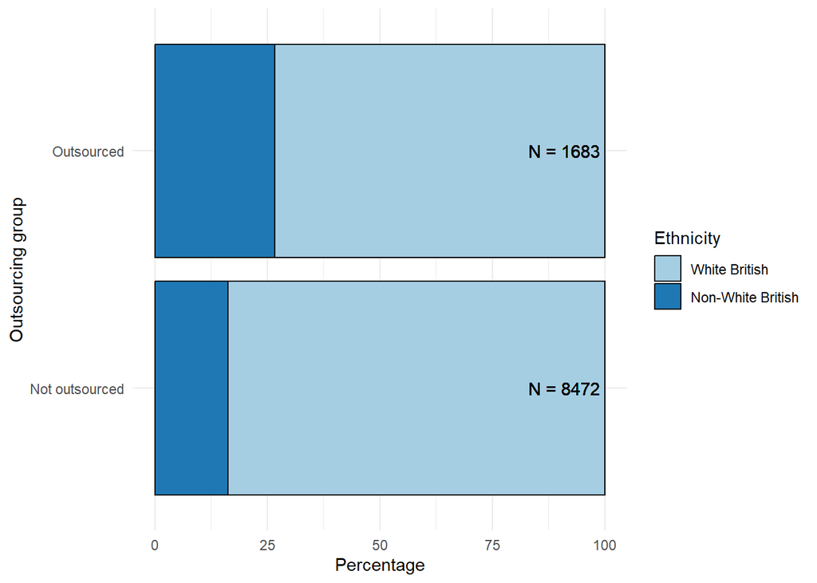

Overall, there is no interaction between being from a minority and outsourced on whether you are low paid. i.e., being from an ethnic minority and outsourced is not associated with being in the low pay group.[^17]

Ethnicity (binary) by outsourcing status and income group(%)

| outsourcing_status | income_group | White British | Non-White British |
| --- | --- | --- | --- |
| Not outsourced | Not low | 84.35 | 15.65 |
| Not outsourced | Low | 86.08 | 13.92 |
| Outsourced | Not low | 71.55 | 28.45 |
| Outsourced | Low | 75.31 | 24.69 |

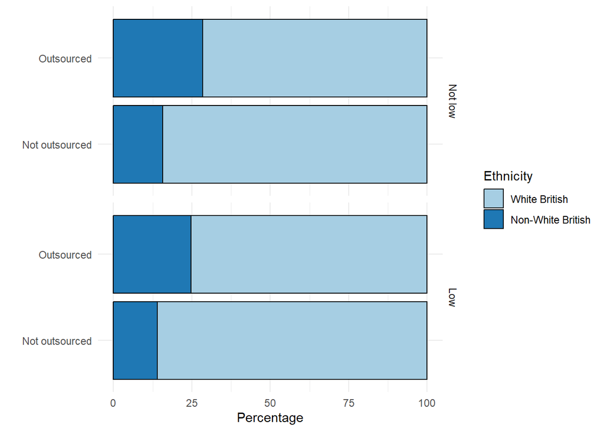

Comparison of ethnicities indicates that some groups are statistically more likely to be outsourced than others[^18]:

- Asian workers are 1.94 times more likely than White workers to be outsourced.
- Black workers are 2.29 times more likely than White workers to be outsourced.
- Mixed Ethnicity workers are 1.83 times more likely than White workers to be outsourced.
- Arab workers are 3.32 times more likely than White workers to be outsourced.

**#ethnicity-disaggregated**

Comparison of more disaggregated ethnicities indicates more nuance[^19]:

- White other workers are 1.43 times more likely than White workers to be outsourced.
- Black African workers are 2.75 times more likely than White workers to be outsourced.
- Mixed other workers are 2.19 times more likely than White workers to be outsourced.
- South Asian workers are 2.25 times more likely than White workers to be outsourced.
- Other workers are 1.62 times more likely than White workers to be outsourced.
- Black other workers are 2.66 times more likely than White workers to be outsourced.
- Arab workers are 3.39 times more likely than White workers to be outsourced.

Black Caribbean and East Asian workers are no more or less likely than White workers to be outsourced.

**#ethnicity-sub-group**

- These differences in ethnicity also shift slightly depending on which outsourced “sub-group” we look at. For example, compared to White British workers, Black outsourced workers are more likely to be in the “outsourced sub-group” meaning they have self-identified as outsourced, or the “agency sub-group”, meaning they are agency workers doing more long-term and ongoing work. **Are there any other interesting points to mention here? Should we do a chart showing this different across sub-groups? Do we need an interpretive comment in this section?**

Breaking down by outsourcing group helps to separate out the *type* of outsourced work people from the ethnicities identified above engage in.[^20] Compared to White British workers,

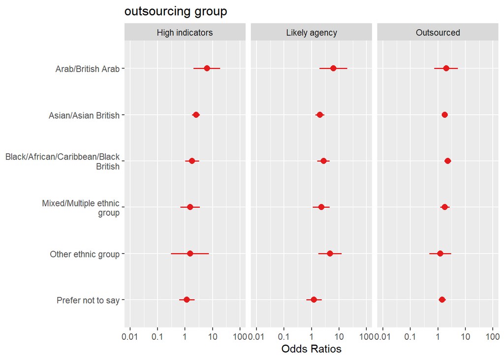

More nuance from disaggregated ethnicities[^21]. Compared to White British workers,

- White other workers are more likely to be outsourced than not outsourced
- Black African workers are more likely to be outsourced, likely agency, or high indicators than not outsourced
- Mixed other workers are more likely to be likely agency workers than not outsourced
- South Asian workers are more likely to be outsourced, likely agency, or high indicators than not outsourced
- Other workers are more likely to be outsourced or likely agency than not outsourced
- Black other workers are more likely to be outsourced than not outsourced
- Arab workers are more likely to be likely agency or high indicators than not outsourced

Again, Black Caribbean and East Asian workers are no more or less likely than White British workers to be engaged in any type of outsourced work.

**#ethnicity-pay-split**

- On the low-pay / high-pay split, you say “*A person is more likely to be in the low income group if they are: Older; Female; Prefer not to say when they arrived, And less likely if they are: Asian/Asian British; Live in North West or Wales; Arrived in the UK in last 30 years*”; Can I confirm this means we don’t see any other significant differences in the ethnicity breakdown if we look at high paid vs low paid workers? If so, let’s clarify what this says about how ethnicity relates to a) outsourced workers being disproportionately low paid, but b) ethnic minority workers being no more likely to be in our low pay group.

*Using the new ethnicity groupings, there is no evidence indicating that any ethnicity is more or less likely to be in the low income group*

**Note to self: This could benefit from stepwise regression**

A person is more likely to be in the low income group if they are:

- Older
- Female
- Don’t have a degree (or don’t know if they have a degree?)
- Are outsourced
- Arrived in the UK in the last year

And less likely if they are:

- Younger
- Male
- Have a degree
- Live in the North West or Wales (compared to London)
- Arrived in the UK in last 30 years

**#migration**

- As you would expect, the vast majority of outsourced workers were born in the UK. However, we still see a significantly higher likelihood of outsourced workers having been born outside of the UK compared to people who aren’t outsourced. While around 14% of non-outsourced workers were born outside of the UK, this rose to just over 24% for outsourced workers – or nearly 1 in 4.
- Overall, people who were born outside of the UK are 1.94 times more likely to be in outsourced work than people who were born here.

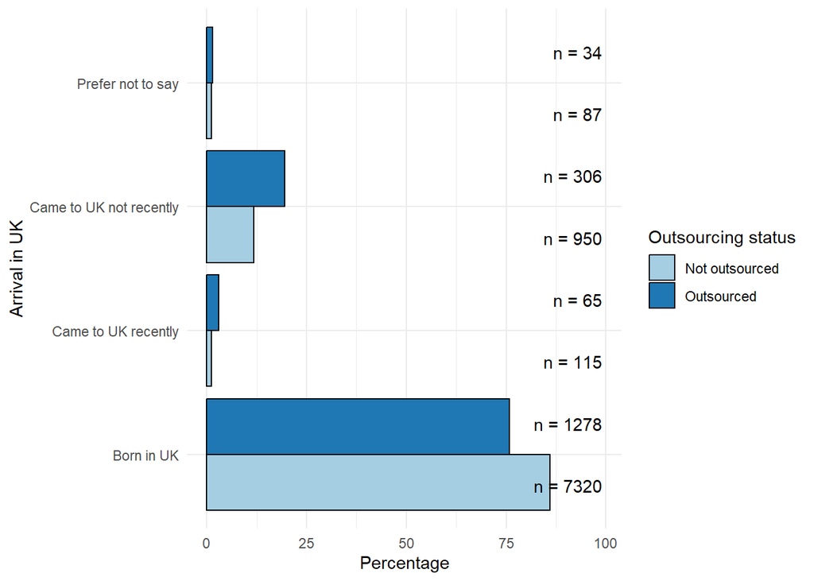

As for non-outsourced workers, the vast majority of outsourced workers are born in the UK. However, people not born in the UK are more likely to be outsourced than people born in the UK. 24.13% of outsourced workers are not born in the UK, compared to 14.08% of non-outsourced workers.[^22] This difference is statistically significant; **outsourced workers are 1.94 times more likely to have been born outside the UK than non-outsourced workers.**[^23]

**#migration-sub-groups**

- This pattern broadly holds across our three outsourcing sub-groups, with nearly no difference in the likelihood of people born outside of the UK being in any one of the three groups.

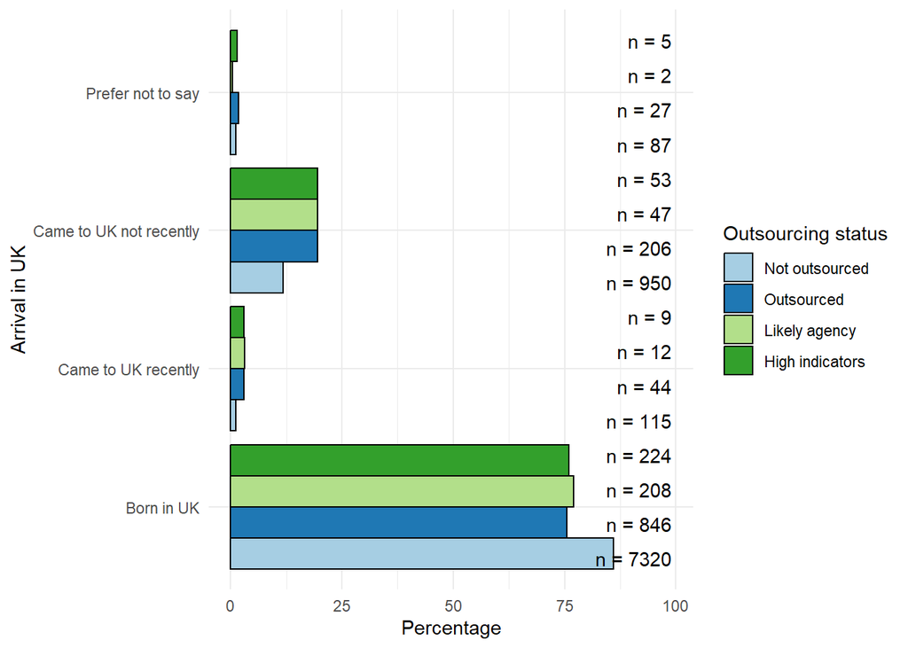

**#ethnicity-migration-interaction. Some attention needed here**

For workers born outside of the UK:

- Among White workers, someone not born in the UK is 1.82 times more likely to be outsourced than someone born in the UK.
- Among workers from Mixed ethnic backgrounds, someone not born in the UK is 2.73 times more likely to be outsourced than someone born in the UK.
- Among Other workers, someone not born in the UK is 0.13 times more likely to be outsourced than someone born in the UK.

For workers from other ethnicities, it doesn’t matter whether you are born in the UK or not – you are equally likely as a Black or an Asian worker to be outsourced, whether you were born in the UK or somewhere else. And compared to a White person born in the UK, Black African and South Asian workers specifically are more likely to be outsourced, whether or not they were born in the UK . Does this need any further detail or explanation

**To discuss confidence in our interpretation in this section: The evidence on ethnicity and country of birth clearly paints a racialised picture of outsourcing, and one with colonial undertones, as Black African and South Asian workers see a higher risk of being outsourced compared to White British workers, regardless of their country of birth. This obviously raises further questions about why, linked to (sector, occupation, labour market inequality and structural racism). Discuss the draft interpretation in the comment on the right.**

**However, workers from non-White ethnic groups are not the only workers who see a higher risk of being outsourced: Non-UK-born White workers are also more likely to be outsourced than UK-born White people . Ethnicity and country of birth interact independently for some groups, but seem to be fundamentally connected for others.**

```
Analysis of Deviance Table

Model 1: outsourcing_status ~ Ethnicity_collapsed + BORNUK_binary
Model 2: outsourcing_status ~ Ethnicity_collapsed * BORNUK_binary
  Resid. Df Resid. Dev Df Deviance      F   Pr(>F)
1     10147     9056.1
2     10141     9032.3  6   23.764 3.9551 0.000591 ***
---
Signif. codes:  0 '***' 0.001 '**' 0.01 '*' 0.05 '.' 0.1 ' ' 1
```

Exploring the intersection of ethnicity and arrival time reveals some patterns whereby the likelihood of a person being outsourced is related to the combinations of ethnicity and whether they were born in the UK.[^24] The plot below shows that

- Among workers born in the UK, a Black worker is 2.01 times more likely to be outsourced than a White worker.
- Among workers born in the UK, a Asian worker is 2.02 times more likely to be outsourced than a White worker.
- Among workers born in the UK, a Other ethnicity worker is 4.3 times more likely to be outsourced than a White other worker.

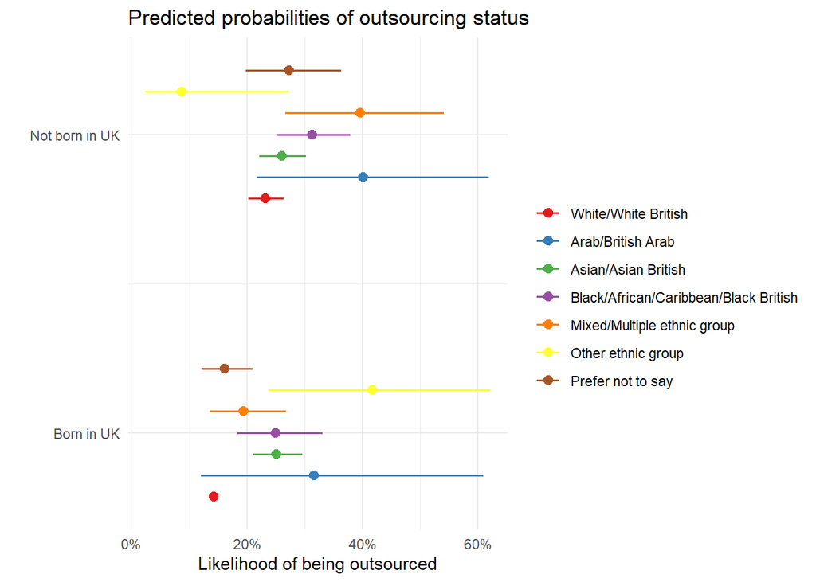

Similarly, the plot below shows that[^25]

- Among White workers, someone not born in the UK is 1.82 times more likely to be outsourced than someone born in the UK.
- Among Mixed workers, someone not born in the UK is 2.73 times more likely to be outsourced than someone born in the UK.
- Among Other workers, someone not born in the UK is 0.13 times as likely (i.e.,87% less likely) to be outsourced than someone born in the UK.

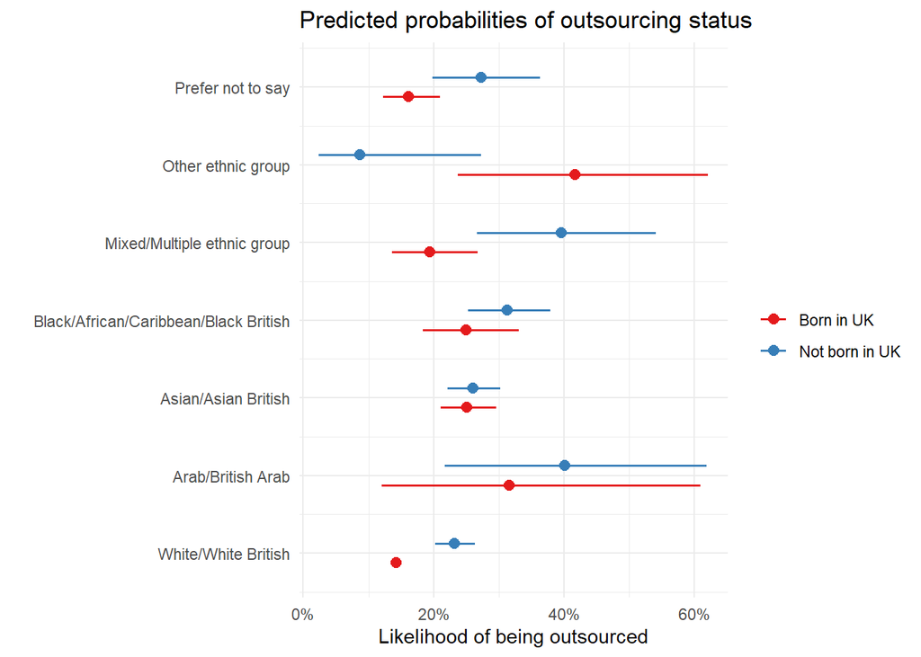

Put differently, being born in the UK is relevant in predicting outsourcing status only for White, Mixed, and Other ethnicities. For the remaining ethnicities, it doesn’t matter whether you are born in the UK or not. And compared to a White person born in the UK, Black and Asian workers are more likely to be outsourced whether or not they were born in the UK.

In summary, people born in the UK are more likely to be outsourced if they are Black, Asian, or ‘Other’, compared to White, and White and mixed ethnicities are more likely to be outsourced if they are not born in the UK, whereas ‘other’ ethnicities are less likely to be outsourced if they were not born in the uk.

**#migration-by-pay-split**

If we do a basic “born UK / not born UK” split, looking by low and high pay, what % of the low-paid workers group were born outside of the UK, vs in the high-paid group?

20.96% of outsourced workers in the low pay group were not born in the UK, compared to 26.39% of people in the not low pay group. This difference is marginally statistically significant; someone in the low income group is less likely to be born outside the UK than someone in the not low income group. This pattern is the same for non outsourced workers, and when we consider the interaction between outsourcing status and migration status, the only factor predicting income group is outsourcing status.

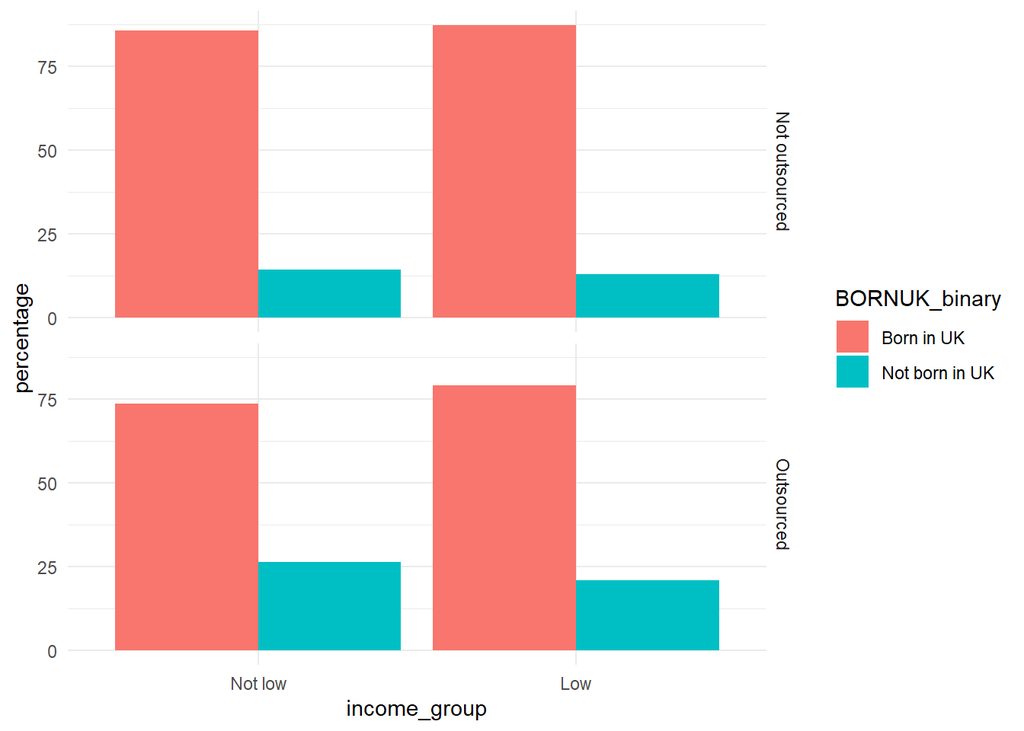

## 2.3 Outsourced workers are on average younger than non-outsourced workers

**#age**

**#age-violin**

Outsourced workers are on average younger than non-outsourced workers. The median age of the outsourced group is 36 , compared to 43 for the not outsourced group.[^26] This difference is statistically significant.[^27]

| Outsourcing group | Mean | Median | Min | Max | Standard dev. | N |
| --- | --- | --- | --- | --- | --- | --- |
| Not outsourced | 42.80 | 43 | 16 | 80 | 13.08 | 8472 |
| Outsourced | 38.63 | 36 | 16 | 78 | 13.07 | 1683 |

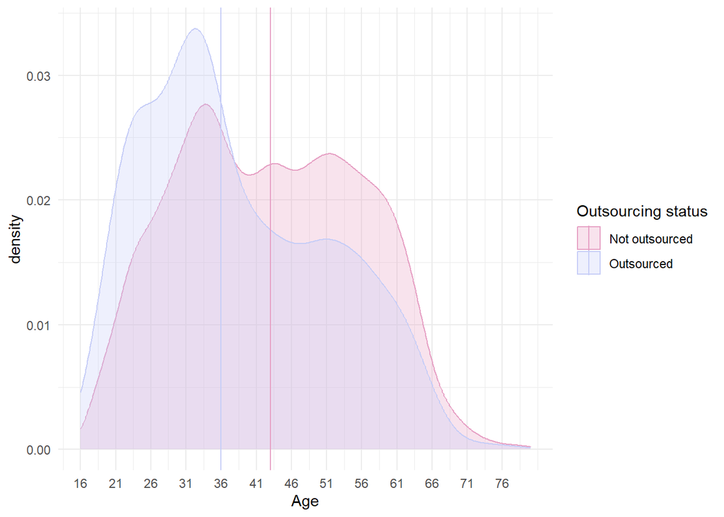

| Outsourcing status | Income group | Mean | Median | Min | Max | Standard dev. | N |
| --- | --- | --- | --- | --- | --- | --- | --- |
| Not outsourced | Not low | 41.97 | 41 | 18 | 78 | 12.47 | 5280 |
| Not outsourced | Low | 42.87 | 43 | 16 | 80 | 15.09 | 1644 |
| Outsourced | Not low | 37.96 | 35 | 18 | 77 | 12.53 | 986 |
| Outsourced | Low | 39.05 | 37 | 16 | 78 | 14.06 | 381 |

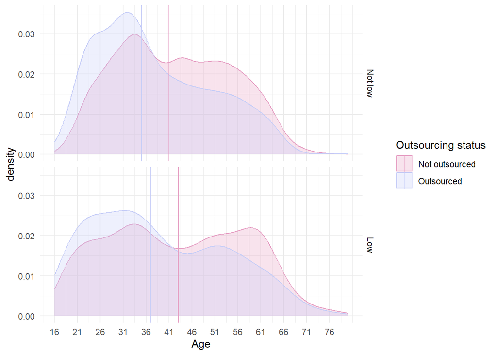

| Outsourcing group | Mean | Median | Min | Max | Standard dev. | N |
| --- | --- | --- | --- | --- | --- | --- |
| Not outsourced | 42.80 | 43 | 16 | 80 | 13.08 | 8472 |
| Outsourced | 38.40 | 35 | 16 | 78 | 13.09 | 1123 |
| Likely agency | 39.80 | 38 | 18 | 77 | 13.49 | 269 |
| High indicators | 38.49 | 35 | 18 | 72 | 12.55 | 291 |

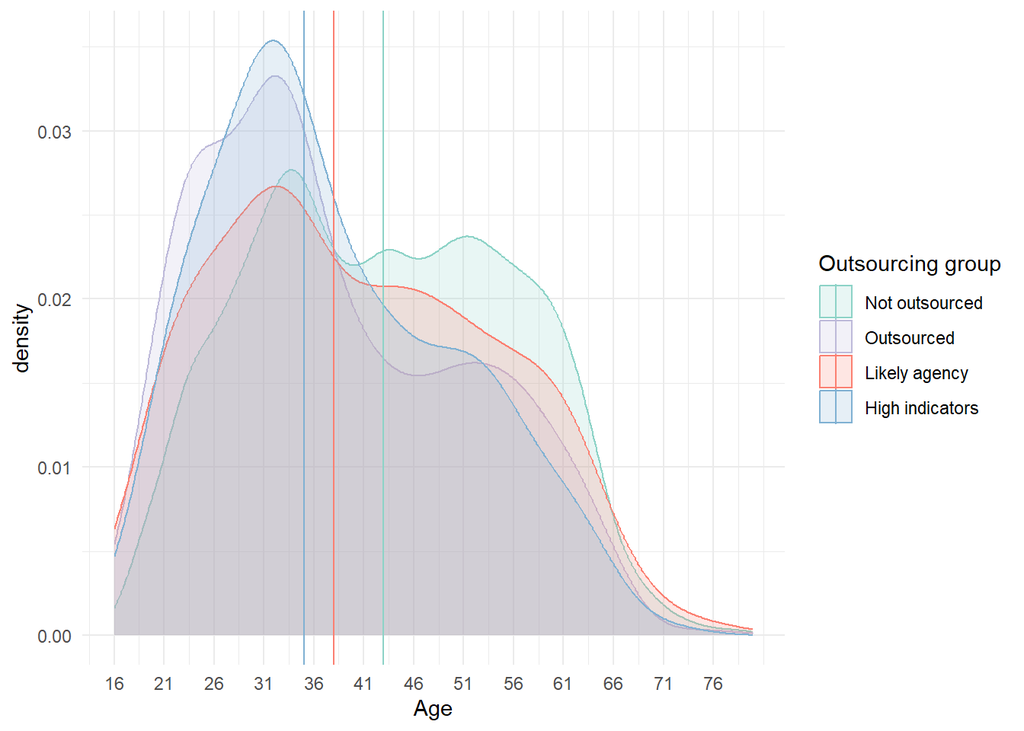

| Outsourcing group | Income group | Mean | Median | Min | Max | Standard dev. | N |
| --- | --- | --- | --- | --- | --- | --- | --- |
| Not outsourced | Not low | 41.97 | 41.00 | 18 | 78.0 | 12.47 | 5280 |
| Not outsourced | Low | 42.87 | 43.00 | 16 | 80.0 | 15.09 | 1644 |
| Outsourced | Not low | 37.81 | 34.52 | 18 | 67.0 | 12.57 | 625 |
| Outsourced | Low | 39.07 | 37.00 | 16 | 78.0 | 13.89 | 272 |
| Likely agency | Not low | 39.33 | 38.00 | 18 | 77.0 | 12.66 | 168 |
| Likely agency | Low | 39.35 | 37.00 | 19 | 71.5 | 15.66 | 63 |
| High indicators | Not low | 37.29 | 35.00 | 18 | 65.0 | 12.25 | 193 |
| High indicators | Low | 38.42 | 34.59 | 19 | 67.0 | 12.82 | 46 |

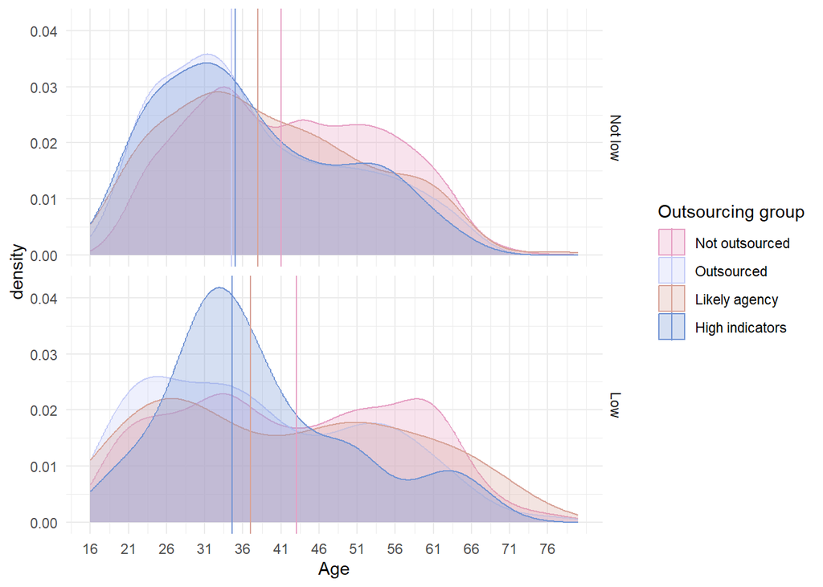

**#gender**

- The evidence also finds meaningful differences by gender between the outsourced and non-outsourced groups in our data. Men make up 56% of the outsourced workforce compared to 47% of the non-outsourced workforce, a nearly 10 percentage point difference.
- Outsourced workers are 1.44 times more likely to be male than female.
- The group with the largest proportion of men in the workforce is the ‘high indicators’ group (66.35%), followed by the ‘likely agency’ group (56.66%), followed by the ‘outsourced’ group (53.94%). Comparison of outsourced and non-outsourced workers finds that
- Someone in the high indicators sub-group is 2.18 times more likely to be male than female.
- Someone in the agency sub-group is 1.45 times more likely to be male than female.
- Someone in the outsourced sub-group is 1.31 times more likely to be male than female.

**#gender-sector**

- Possible addition: Will readers want to know more about how this intersects with the roles or sectors with higher rates of outsourcing – even if this is just an interpretive comment from us on how gender interacts with jobs and sectors more generally in the labour market?

The outsourced workforce consists of a greater proportion of males than the non-outsourced workforce.[^29] Men make up 56% of the outsourced workforce compared to 47% of the non-outsourced workforce. This difference is statistically significant; outsourced workers, compared to non-outsourced workers, are 1.44 times more likely to be male than female.[^30]

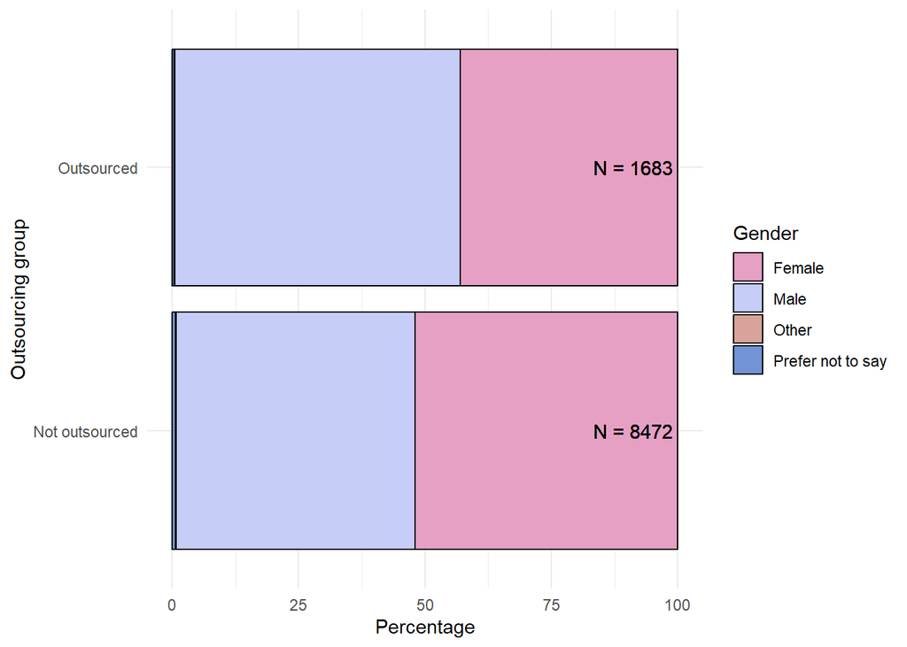

Breaking down by outsourcing group, we find that the group with the largest proportion of men in the workforce is the ‘high indicators’ group (66.35%), followed by the ‘likely agency’ group (56.66%), followed by the ‘outsourced’ group (53.94%). Statistically speaking, compared to a not outsourced person,

- Someone in the high indicators group is 2.18 times more likely to be male than female.
- Someone in the likely agency group is 1.45 times more likely tobe male than female.
- Someone in the outsourced group is 1.31 times more likely tobe male than female.

Additionally, people identifying as ‘Other’ gender are absent from the high indicators and likely agency groups, though given the small N (14) for this group, this finding is unlikely to be meaningful.

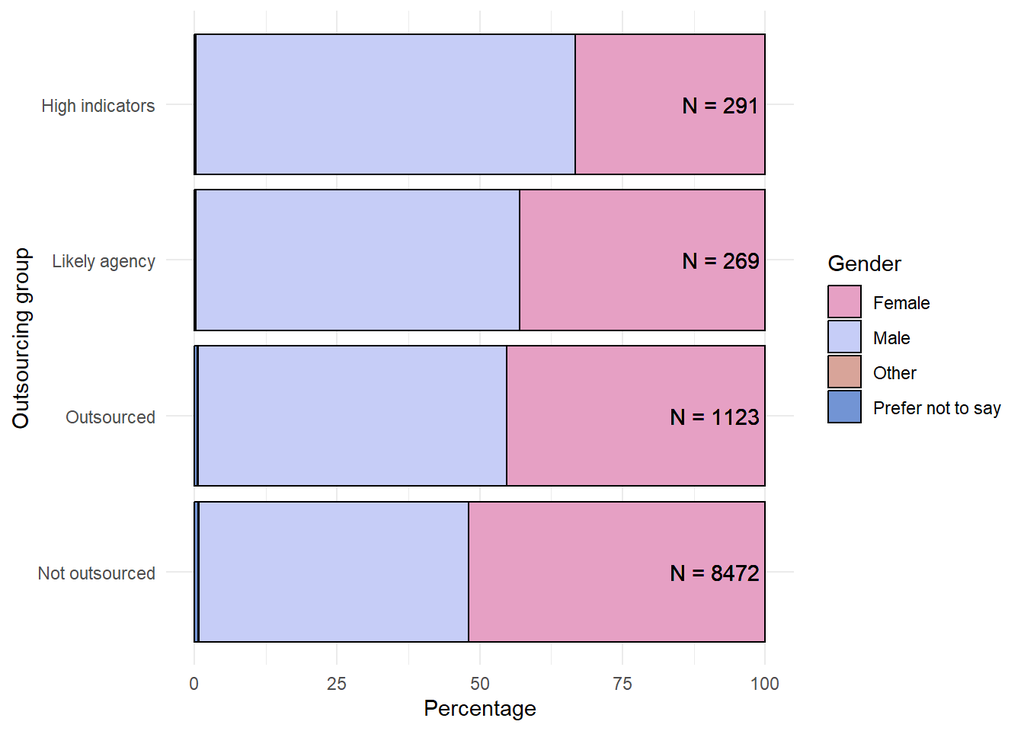

## 2.4 Outsourced workers are more likely to work in some sectors than others; but seem to be spread across the labour market

**#sectors**

Here we explore what proportion of workers in each sector are outsourced.[^31]

The plot below shows the proportion of outsourced and not outsourced workers within each sector. I.e. this is showing what sectors have higher and lower proportions of outsourced workers.

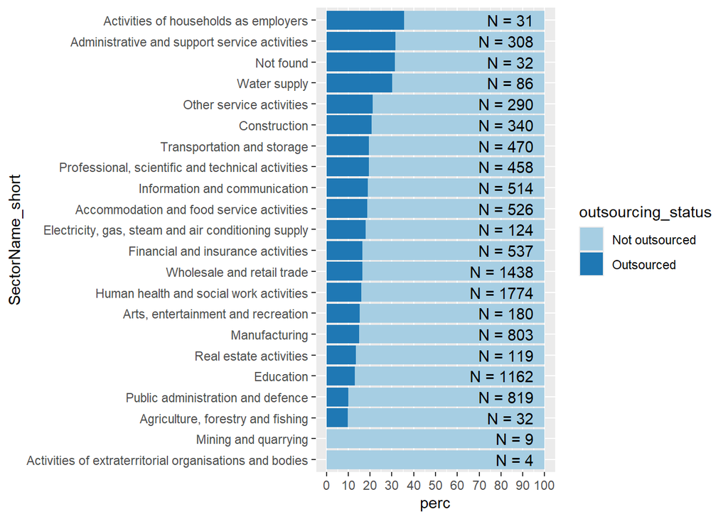

The top three Sectors with the highest proportion of outsourced workers are:

- ACTIVITIES OF HOUSEHOLDS AS EMPLOYERS; UNDIFFERENTIATED GOODS-AND SERVICES-PRODUCING ACTIVITIES OF HOUSEHOLDS FOR OWN US (note that N = 31)
- ADMINISTRATIVE AND SUPPORT SERVICE ACTIVITIES
- WATER SUPPLY; SEWERAGE, WASTE MANAGEMENT AND REMEDIATION ACTIVITIES

Note that for an undefined sector (‘Not found’) contained one of the largest proportions of outsourced workers (31% of workers in the ‘Not found’ category were outsourced).

A key takeaway here is that whereas the total outsourced population is 17%, this figure varies by sector, from 0% for Mining… and Extraterritoral organisations… all the way to 36% for Activities of households as employers, with 5 out 20 sectors having at least 20% of their workforce outsourced.

**#sectors-ogroup**

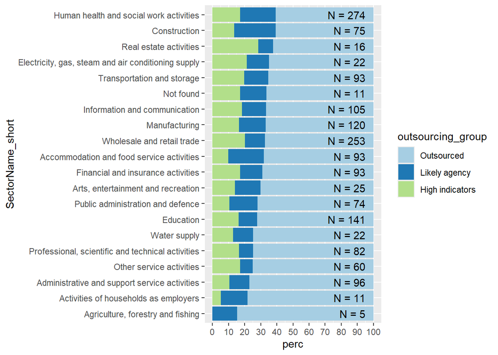

# 3 Pay

**’#pay**

**#pay-violin**

The tables and plots below show descriptive statistics on income and its distribution for outsourced and non-outsourced people. Regression analysis shows that **outsourced workers are on average paid £2170 less annually than non-outsourced workers**.[^32] Per week, **outsourced workers are on average paid £47 less than non-outsourced workers**

Weekly stats here[^33]

| Outsourcing status | n | Mean | Median | Min | Max | Standard dev. |
| --- | --- | --- | --- | --- | --- | --- |
| Not outsourced | 6924 | 26781.29 | 25120.67 | 2000 | 66250 | 13365.63 |
| Outsourced | 1367 | 24611.38 | 23061.99 | 2400 | 66108 | 12998.56 |

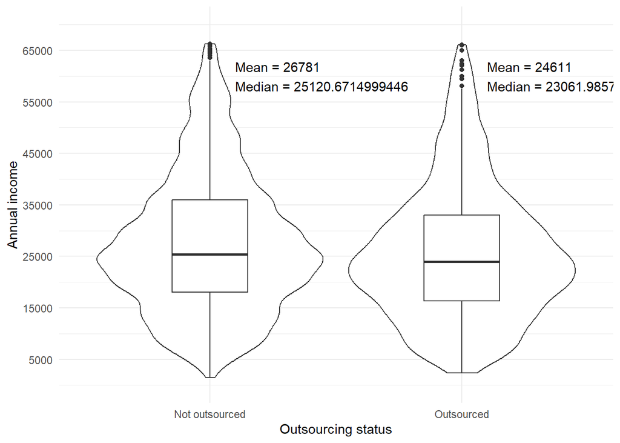

| Outsourcing status | n | Mean | Median | Min | Max | Standard dev. |
| --- | --- | --- | --- | --- | --- | --- |
| Not outsourced | 6924 | 575.41 | 539.73 | 42.97 | 1423.42 | 287.17 |
| Outsourced | 1367 | 528.79 | 495.50 | 51.57 | 1420.37 | 279.28 |

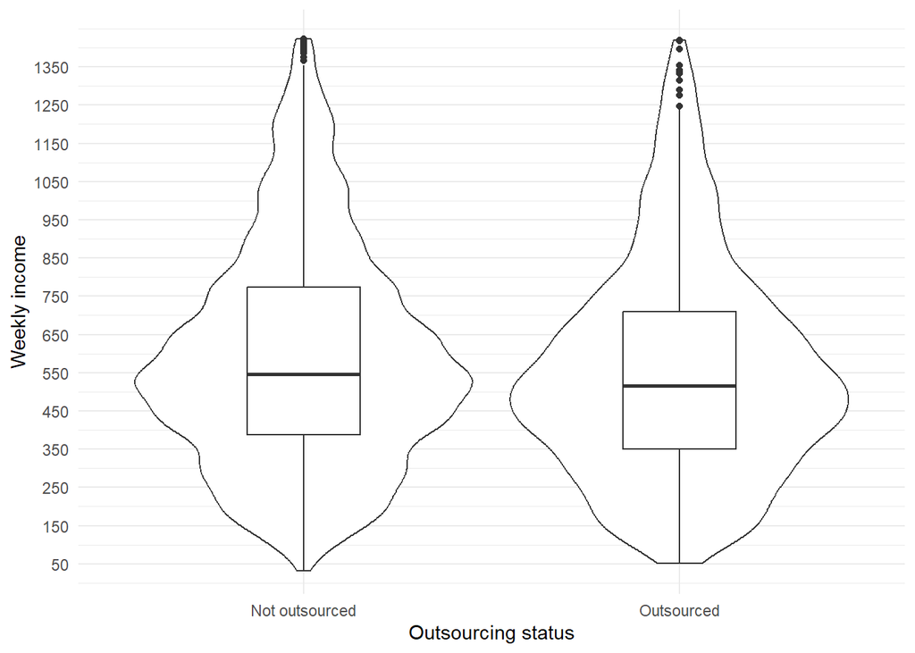

Weekly stats here[^35]

| Outsourcing group | n | Mean | Median | Min | Max | Standard dev. |
| --- | --- | --- | --- | --- | --- | --- |
| Not outsourced | 6924 | 26781.29 | 25120.67 | 2000.0 | 66250.00 | 13365.63 |
| Outsourced | 897 | 23680.86 | 22165.73 | 2400.0 | 66000.00 | 12783.87 |
| Likely agency | 231 | 25081.11 | 22800.00 | 3194.7 | 65846.67 | 13702.90 |
| High indicators | 239 | 27921.52 | 25860.36 | 4644.0 | 65000.00 | 12629.15 |

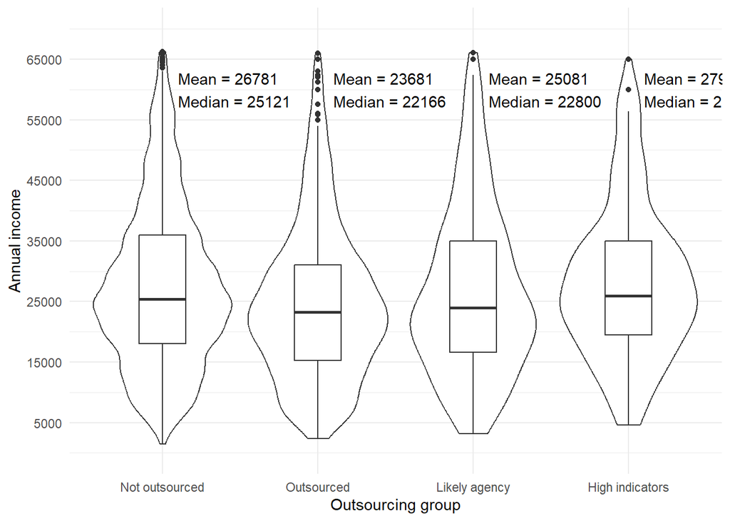

| Outsourcing group | n | Mean | Median | Min | Max | Standard dev. |
| --- | --- | --- | --- | --- | --- | --- |
| Not outsourced | 6924 | 575.41 | 539.73 | 42.97 | 1423.42 | 287.17 |
| Outsourced | 897 | 508.80 | 476.24 | 51.57 | 1418.05 | 274.67 |
| Likely agency | 231 | 538.88 | 489.87 | 68.64 | 1414.75 | 294.41 |
| High indicators | 239 | 599.91 | 555.62 | 99.78 | 1396.56 | 271.34 |

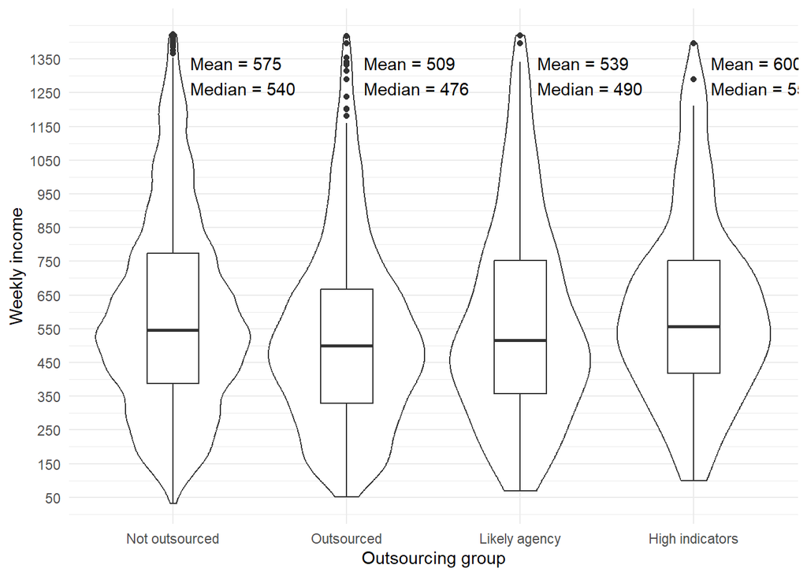

This difference increases to £2943 annually (£63 per week) when we take into account Age, Gender, Education, Ethnicity, Region, and Arrival Time. [^36] This analysis shows that all other variables, apart from Age, are in some way relevant to income. On average, and controlling for each of the other variables in the model.

Annually:

- Men earn £7021 more than women.
- People who have a degree earn £8198 more than people without a degree.
- Workers in all non-London regions earn less than workers in London
  - East Midlands: -£5755
  - East of England: -£4060
  - North East: -£4813
  - North West: -£4451
  - Northern Ireland: -£6647
  - Scotland: -£5428
  - South East: -£3381
  - Wales: -£5345
  - West Midlands: -£4981
  - Yorkshire and the Humber: -£5489
- People who arrived in the UK within the last year earn £6262 less than people born in the UK
- People who arrived in the UK within the last 3 years earn £2561 less than people born in the UK
- People who arrived in the UK within the last 5 years earn £2306 less than people born in the UK
- People who arrived within the last 30 years earn £3292 more than people born in the UK.

Weekly[^37]:

- Men earn £151 more than women.
- People who have a degree earn £176 more than people without a degree.
- Workers in all non-London regions earn less than workers in London
  - East Midlands: -£124
  - East of England: -£87
  - North East: -£103
  - North West: -£96
  - Northern Ireland: -£143
  - Scotland: -£117
  - South East: -£73
  - Wales: -£115
  - West Midlands: -£107
  - Yorkshire and the Humber: -£118
- People who arrived in the UK within the last year earn £135 less than people born in the UK
- People who arrived in the UK within the last 3 years earn £55 less than people born in the UK
- People who arrived in the UK within the last 5 years earn £50 less than people born in the UK
- People who arrived within the last 30 years earn £71 more than people born in the UK.

## 3.1 Gender pay gap

**#gender-pay-gap**

- On average within our sample, male workers earn £6400 more than female workers per year; but further exploration of how pay relates to gender for outsourced workers suggests that this gender pay gap doesn’t differ in a statistically significant way depending on whether workers are outsourced or not
- For female outsourced workers, this suggests that being an outsourced worker neither exacerbates nor diminishes the gender pay gap they face compared to male workers. **Check what this controls for**

### 3.1.1 Outsourcing status

| outsourcing_status | Gender | n | mean | median | min | max | stdev |
| --- | --- | --- | --- | --- | --- | --- | --- |
| Not outsourced | Female | 4321 | 23750.33 | 22199.18 | 2234.057 | 66249.37 | 12612.378 |
| Not outsourced | Male | 3576 | 30197.26 | 28000.00 | 2400.000 | 66000.00 | 13346.555 |
| Not outsourced | Other | 11 | 28154.06 | 29713.06 | 10800.000 | 50000.00 | 15199.138 |
| Not outsourced | Prefer not to say | 57 | 28650.68 | 25260.52 | 13684.996 | 64000.00 | 17065.444 |
| Outsourced | Female | 666 | 20318.32 | 19600.50 | 2400.000 | 65000.00 | 11603.484 |
| Outsourced | Male | 863 | 27983.89 | 26000.00 | 3600.000 | 66085.73 | 13040.672 |
| Outsourced | Other | 2 | 16230.00 | 21011.55 | 8460.000 | 24000.00 | 9886.687 |
| Outsourced | Prefer not to say | 7 | 21245.30 | 28425.08 | 11635.714 | 42000.50 | 16565.978 |

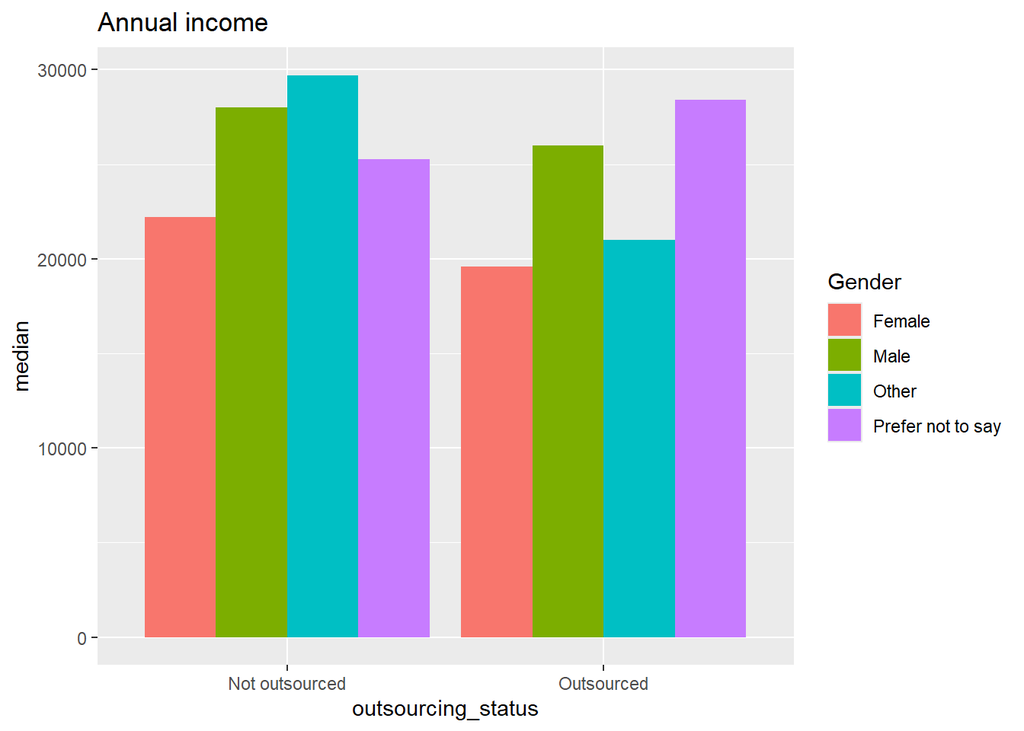

| outsourcing_status | Gender | n | mean | median | min | max | stdev |
| --- | --- | --- | --- | --- | --- | --- | --- |
| Not outsourced | Female | 4321 | 510.2894 | 476.9621 | 48.00000 | 1423.4057 | 270.9842 |
| Not outsourced | Male | 3576 | 648.8054 | 601.5961 | 51.56538 | 1418.0479 | 286.7584 |
| Not outsourced | Other | 11 | 604.9061 | 638.4022 | 232.04420 | 1074.2787 | 326.5622 |
| Not outsourced | Prefer not to say | 57 | 615.5762 | 542.7368 | 294.03000 | 1375.0767 | 366.6609 |
| Outsourced | Female | 666 | 436.5508 | 421.1280 | 51.56538 | 1396.5623 | 249.3075 |
| Outsourced | Male | 863 | 601.2499 | 558.6249 | 77.34807 | 1419.8899 | 280.1863 |
| Outsourced | Other | 2 | 348.7109 | 451.4451 | 181.76796 | 515.6538 | 212.4211 |
| Outsourced | Prefer not to say | 7 | 456.4674 | 610.7292 | 250.00000 | 902.4048 | 355.9295 |

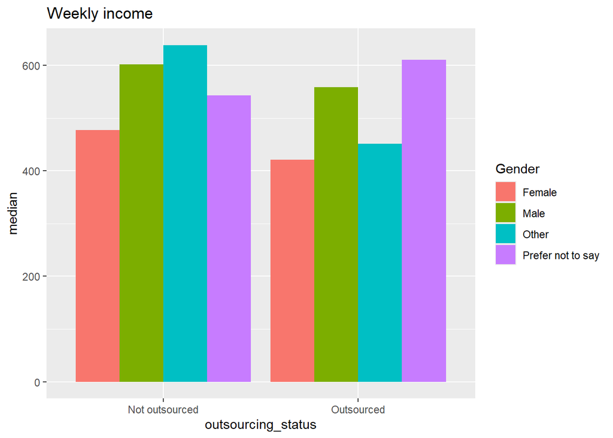

**Annual**[^38]:

Exploring the gender pay gap by outsourcing status indicates that the pay gap does not differ depending on whether workers are outsourced our not. For non-outsourced workers, females are paid £5800.82 less than males. For outsourced workers, females are paid £6399.5 less than males. The difference between non-outsourced and outsourced workers is not significant.

**Weekly**[^39]:

Exploring the gender pay gap by outsourcing status indicates that the pay gap does not differ depending on whether workers are outsourced our not. For non-outsourced workers, females are paid £124.63 less than males. For outsourced workers, females are paid £137.5 less than males. The difference between non-outsourced and outsourced workers is not significant.

The gender by outsourcing status is also not relevant for whether a worker is low income (i.e. non-sig relationship with income_group).

### 3.1.2 Outsourcing group

The gender by outsourcing group is also not relevant for whether a worker is low income (i.e. non-sig relationship with income_group).

**#gender-income-group**

- In particular, people are more likely to be in our low-paid outsourced group if they are female, or older workers .

Income group[^42]

A person is more likely to be in the low income group if they are:

- Older
- Female
- Don’t have a degree (or don’t know if they have a degree?)
- Are outsourced
- Arrived in the UK in the last year

And less likely if they are:

- Younger
- Male
- Have a degree
- Live in the North West or Wales (compared to London)
- Arrived in the UK in last 30 years

**#gender-by-pay-split**

Is there already a basic low / high pay split for gender? I know you talk about women being more likely to be in the low-paid group, but again not sure if there is just a basic “women make up x% of low pay group and x% of not low pay group”?

60.34% of outsourced workers in the low pay group were female, compared to 35.85% of outsourced workers in the not low pay group. This difference is statistically significant; women are more likely to be in the low income group. This pattern is the same for non outsourced workers, and there is no interaction effect; irrespective of outsourcing status, women are more likely to be low paid, and irrespective of gender, outsourced people are more likely to be low paid.

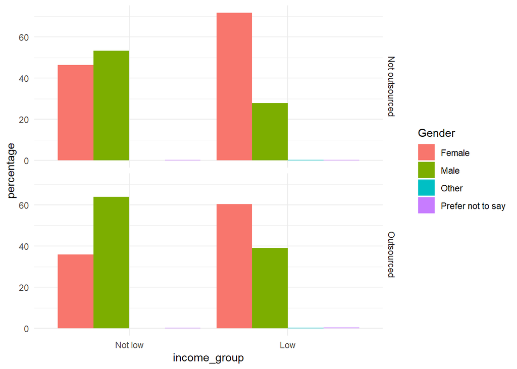

**#pay-gap-sector**

**#regions**

- In London, around 25% of workers are outsourced – the highest proportion of any region in the UK. London is followed by the East Midlands (19%) and West Midlands (18%) in the share of workers in the region who are outsourced, with the East of England being the region with the lowest share of outsourced workers as part of the total employed workforce, at 13%.
- Possible addition: Should this include some comment on WHY we think this might be the case? Should we look at sectoral splits in London, compared to everywhere else, to see whether there are significant sector differences that might explain this trend?

The plot below shows the proportion of workers within each region who are outsourced.[^43]

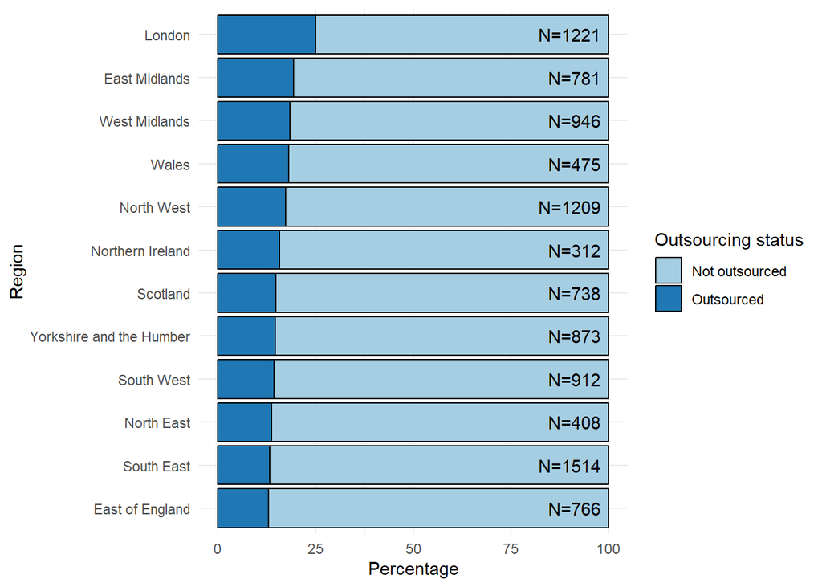

Below we map the workforce composition in each region. The first map emphasises that London has the highest concentration of outsourced workers (25%).

[figure not shown]

The second map excludes London so that is easier to see how the remaining regions compare. After London, the regions with the highest proportion of outsourced workers are:

1. East Midlands (19%)
2. West Midlands (18%)
3. Wales (18%)
4. North West (17%)
5. Northern Ireland (16%)

[figure not shown]

We can also explore how the the entire UK workforce is distributed across the country.[^44] The table and map below show the percentage of outsourced workers in each region as a proportion of the total UK workforce. They show where the UK’s outsourced workforce is concentrated. The regions with the highest share of the UK’s outsourced workforce are:

1. London (21%)
2. North West (11%)
3. South East (11%)
4. West Midlands (9%)
5. East Midlands (8%)

| Region | Frequency | Sum | Percentage |
| --- | --- | --- | --- |
| London | 357.35 | 1708.36 | 20.92 |
| North West | 189.39 | 1708.36 | 11.09 |
| South East | 188.47 | 1708.36 | 11.03 |
| West Midlands | 161.49 | 1708.36 | 9.45 |
| East Midlands | 140.50 | 1708.36 | 8.22 |
| Scotland | 125.82 | 1708.36 | 7.37 |
| East of England | 125.49 | 1708.36 | 7.35 |
| South West | 120.50 | 1708.36 | 7.05 |
| Yorkshire and the Humber | 119.46 | 1708.36 | 6.99 |
| Wales | 83.25 | 1708.36 | 4.87 |
| North East | 53.06 | 1708.36 | 3.11 |
| Northern Ireland | 43.56 | 1708.36 | 2.55 |

[figure not shown]

## Footnotes

[^1]: outputs/data/total_outsourced.csv
[^2]: outputs/data/total_outsourced_2.csv
[^3]: outputs/data/number_of_groups.csv
[^4]: outputs/data/status_by_ethnicity.csv
[^5]: outputs/data/status_by_ethnicity_full.csv
[^6]: outputs/data/status_by_ethnicity_income_group.csv
[^7]: outputs/data/status_by_ethnicity_full_income_group.csv
[^8]: outputs/data/group_by_ethnicity.csv
[^9]: outputs/data/group_by_ethnicity_full.csv
[^10]: outputs/data/group_by_ethnicity_income_group.csv
[^11]: outputs/data/group_by_ethnicity_full_income_group.csv
[^12]: outputs/data/status_by_gender.csv
[^13]: outputs/data/status_by_gender_income_group.csv
[^14]: outputs/data/group_by_gender.csv
[^15]: outputs/data/group_by_gender_income_group.csv
[^16]: outputs/data/ethnicity_stats_1.csv & outputs/data/ethnicity_binary_o-status_inferential_tab.csv
[^17]: outputs/data/ethnicity_binary_income_group.csv
[^18]: outputs/data/ethnicity_model_inferential.csv
[^19]: outputs/data/ethnicity_model_inferential_2.csv
[^20]: outputs/data/ethnicity_ogroup_inferential_tab.csv
[^21]: outputs/data/ethnicity_ogroup_inferential_tab_2.csv
[^22]: outputs/data/arrival_in_UK_stats.csv
[^23]: outputs/data/bornuk_ostatus_inferential_tab.csv
[^24]: outputs/data/bornUK_binary_contrasts.csv
[^25]: outputs/data/region_stats_2.csv
[^26]: outputs/data/region_stats_2.csv
[^27]: outputs/data/region_stats_3.csv
[^28]: outputs/data/sector_summary_3.csv
[^29]: outputs/data/sector_summary_3.csv
[^30]: [../outputs/data/gender_inferential_tab.csv](https://github.com/JustKnowledge-UK/jrf_nat_rep/blob/main/outputs/data/gender_inferential_tab.csv)
[^31]: outputs/data/sector_summary_3.csv
[^32]: outputs/data/income_stats_o-group.csv & outputs/data/model_income_by_o-group.csv
[^33]: outputs/data/weekly_income_stats_o-status.csv & outputs/data/model_income_by_o-status_weekly.csv
[^34]: outputs/data/income_stats_o-group.csv & outputs/data/model_income_by_o-group.csv
[^35]: outputs/data/weekly_income_stats_o-group.csv & outputs/data/model_income_by_o-group_weekly.csv
[^36]: outputs/data/model_2_income_by_o-status.csv
[^37]: outputs/data/model_2_income_by_o-status_weekly.csv
[^38]: outputs/data/o-status_gender_gap.csv & outputs/data/mod_o-status_gender.csv
[^39]: outputs/data/o-status_gender_gap_weekly.csv & outputs/data/mod_o-status_gender_weekly.csv
[^40]: outputs/data/o-group_gender_gap.csv.csv & outputs/data/mod_o-group_gender.csv
[^41]: outputs/data/o-group_gender_gap_weekly.csv & outputs/data/mod_o-group_gender_weekly.csv
[^42]: [../outputs/data/income_group_outsourcing.csv](https://github.com/JustKnowledge-UK/jrf_nat_rep/blob/main/outputs/data/income_group_outsourcing.csv)
[^43]: outputs/data/region_stats_2.csv
[^44]: outputs/data/region_stats_3.csv